# Diffraction from a circular aperture

For theory see *Optics f2f*, https://global.oup.com/ukhe/product/optics-f2f-9780198786795?cc=gb&lang=en&

```python
import numpy as np
import matplotlib.pyplot as plt
```

# Aperture function

First define an aperture function $A(x,y,x_0,y_0)$.

We use a super gaussian to give slightly smoothed edges.

We also allow for a positional offset $(x_0,y_0)$ in the input plane.

This allows us to add multiple aperatures if desired.

If you want an obstacle instead of an aperature use $1 -$ this function.

The cover image of *Optics f2f*, Figs. 5.9 and 5.10 are all made with this code.

```python
def Aperture(x,y,x0,y0): # function defining aperture
        w1 = 850.0 # disc radius
        p = 32 # sharpness of the edge
        return np.exp(-((x-x0)**2+(y-y0)**2)**p/w1**p)
```

# $xy$ plane

Now we define the spatial extent in the $xy$ plane.

All dimensions in units of $\lambda$.

We can set the resolution, $\delta x$, to less than the wavelength but then code takes longer.

```python
xmax = 128 # dimensions of screen in units of lambda
dx = 1.0 # resolution in units of lambda

x = np.arange(-xmax, xmax, dx)
x_pts = np.size(x)
y = np.arange(-xmax, xmax, dx)
X,Y = np.meshgrid(x, y)
```

# Angular spectrum propagator

See p. 98 - 99 of *Optics f2f*

We will work in units of a central wavelength but allow some tuning using the parameter $l_0$

```python
def Prop(kx,ky,z,l0):
    k=2.0*np.pi/l0 # k=2pi/lambda with lambda_0 = 1 e.g. 530 nm
    k2=k*k
    return np.exp(1.j*np.sqrt(k2-kx*kx-ky*ky)*z)

kmax = 1.0*np.pi/dx
dk = 2*kmax/x_pts
kx = np.arange(-kmax,kmax,dk)
kx = kx.astype('complex') #Notes on complex types http://www.scipy.org/NegativeSquareRoot

KX, KY = np.meshgrid(kx, kx)
```

# Intensity distribtion

Using the Hedgehog equation eqn (6.29) on p. 98 of *Optics f2f*.

We calculate the intensity ${\cal I}(x,y,z)$ everywhere downstream of the aperture.

Repeat for red, green and blue light.

```python
from numpy.fft import fft2, ifft2, fftshift
import time

startTime = time.time()

zmax = 3*256
z_pts = int(zmax/dx) # 1000 with resolution 0.05 takes 80 s

H0 = Aperture(X, Y, 0, -80)
IR = np.zeros((x_pts,x_pts,z_pts))
for ii in range(0,z_pts):
    z = ii*dx
    P0 = Prop(KX,KY,z,1.23)  # 650/530 = 1.23
    H1 = ifft2(P0*fftshift(fft2(H0))) # propagation equation
    FZr = H1.real
    FZi = H1.imag
    IR[:,:,ii] = FZr*FZr+FZi*FZi # calculate modulus squared

H0 = Aperture(X, Y, 0, 0)
IG = np.zeros((x_pts,x_pts,z_pts))
for ii in range(0,z_pts):
    z = ii*dx
    P0 = Prop(KX,KY,z,1.0)
    H1 = ifft2(P0*fftshift(fft2(H0)))
    FZr = H1.real
    FZi = H1.imag
    IG[:,:,ii] = FZr*FZr+FZi*FZi

H0 = Aperture(X, Y, 0, 80)
IB = np.zeros((x_pts,x_pts,z_pts))
for ii in range(0,z_pts):
    z = ii*dx
    P0 = Prop(KX,KY,z,0.83) # 440/530 = 0.83
    H1 = ifft2(P0*fftshift(fft2(H0))) # propagation equation
    FZr = H1.real
    FZi = H1.imag
    IB[:,:,ii] = FZr*FZr+FZi*FZi # calculate modulus squared

endTime = (time.time() - startTime)
print('Time in seconds: ' + str(endTime))
```

```
Time in seconds: 20.563201189041138
```

# Intensity image in $xz$ and $xy$ at position $z$

Now plot images of the intensity patterns.

We add the red, blue and green into the RGB channels of the image.

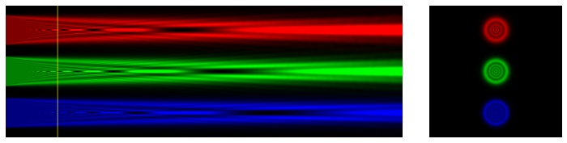

```python
z_pos = 100

ymax = xmax # y range in wavelengths
yr = int(ymax/dx)

brightness = 0.5 #saturation

R = brightness * IR[int(x_pts/2)-yr:int(x_pts/2)+yr,int(x_pts/2),:]
G = brightness * IG[int(x_pts/2)-yr:int(x_pts/2)+yr,int(x_pts/2),:]
B = brightness * IB[int(x_pts/2)-yr:int(x_pts/2)+yr,int(x_pts/2),:]

R[:,int(z_pos*dx)] += np.ones(x_pts)
G[:,int(z_pos*dx)] += np.ones(x_pts)

R = np.clip(R,0.0,1.0)
G = np.clip(G,0.0,1.0)
B = np.clip(B,0.0,1.0)

RGB = np.dstack((R, G, B))

fig = plt.figure(constrained_layout=False,figsize=(10, 3))
gs1 = fig.add_gridspec(nrows=1, ncols=4, left=0.0, right=1.0, wspace=0.0, hspace=0.01)
ax1 = fig.add_subplot(gs1[0, :-1])
ax2 = fig.add_subplot(gs1[0, -1])

ax1.imshow(RGB)
ax1.axison = False

R = IR[int(x_pts/2)-yr:int(x_pts/2)+yr, int(x_pts/2)-yr:int(x_pts/2)+yr, int(z_pos*dx)]
G = IG[int(x_pts/2)-yr:int(x_pts/2)+yr, int(x_pts/2)-yr:int(x_pts/2)+yr, int(z_pos*dx)]
B = IB[int(x_pts/2)-yr:int(x_pts/2)+yr, int(x_pts/2)-yr:int(x_pts/2)+yr, int(z_pos*dx)]

brightness = 0.5 #saturation
Rc = np.clip(brightness*R,0.0,1.0)
Gc = np.clip(brightness*G,0.0,1.0)
Bc = np.clip(brightness*B,0.0,1.0)

RGBc = np.dstack((Rc, Gc, Bc))

ax2.imshow(RGBc)
ax2.axison = False
```

# Interactive figure as function of propagation distance $z$

To make an interactive html files see https://nikolasibalic.github.io/Interactive-Publishing/

```python
from ifigures import *
from ifigures.my_plots import *

def Circ_Aperture_Fig(z_pos):
    ymax = xmax # y range in wavelengths
    yr = int(ymax/dx)

    brightness = 0.5 #saturation

    R = brightness * IR[int(x_pts/2)-yr:int(x_pts/2)+yr,int(x_pts/2),:]
    G = brightness * IG[int(x_pts/2)-yr:int(x_pts/2)+yr,int(x_pts/2),:]
    B = brightness * IB[int(x_pts/2)-yr:int(x_pts/2)+yr,int(x_pts/2),:]

    R[:,int(z_pos*dx)] += np.ones(x_pts)
    G[:,int(z_pos*dx)] += np.ones(x_pts)

    R = np.clip(R,0.0,1.0)
    G = np.clip(G,0.0,1.0)
    B = np.clip(B,0.0,1.0)

    RGB = np.dstack((R, G, B))

    fig = plt.figure(constrained_layout=False,figsize=(10, 3))
    gs1 = fig.add_gridspec(nrows=1, ncols=4, left=0.0, right=1.0, wspace=0.0, hspace=0.01)
    ax1 = fig.add_subplot(gs1[0, :-1])
    ax2 = fig.add_subplot(gs1[0, -1])

    ax1.imshow(RGB)
    ax1.axison = False

    R = IR[int(x_pts/2)-yr:int(x_pts/2)+yr, int(x_pts/2)-yr:int(x_pts/2)+yr, int(z_pos*dx)]
    G = IG[int(x_pts/2)-yr:int(x_pts/2)+yr, int(x_pts/2)-yr:int(x_pts/2)+yr, int(z_pos*dx)]
    B = IB[int(x_pts/2)-yr:int(x_pts/2)+yr, int(x_pts/2)-yr:int(x_pts/2)+yr, int(z_pos*dx)]

    brightness = 0.5 #saturation
    Rc = np.clip(brightness*R,0.0,1.0)
    Gc = np.clip(brightness*G,0.0,1.0)
    Bc = np.clip(brightness*B,0.0,1.0)

    RGBc = np.dstack((Rc, Gc, Bc))

    ax2.imshow(RGBc)
    ax2.axison = False
    return (fig,'')

figure_example1 = InteractiveFigure(Circ_Aperture_Fig,
                z_pos = RangeWidgetViridis(0, 3*250, 5),
               )

figure_example1.saveStandaloneHTML("Circ_Aperture_interactive.html")

figure_example1.show()
```

[interactive chart not shown]

# Animate

This makes an animation but not as pretty or useful as interactive figure.

```python
import gif

@gif.frame

def Circ_Aperture(z_pos):
    ymax = xmax # y range in wavelengths
    yr = int(ymax/dx)

    brightness = 0.25 #saturation

    R = brightness * IR[int(x_pts/2)-yr:int(x_pts/2)+yr,int(x_pts/2),:]
    G = brightness * IG[int(x_pts/2)-yr:int(x_pts/2)+yr,int(x_pts/2),:]
    B = brightness * IB[int(x_pts/2)-yr:int(x_pts/2)+yr,int(x_pts/2),:]

    R[:,int(z_pos*dx)] += np.ones(x_pts)
    G[:,int(z_pos*dx)] += np.ones(x_pts)

    R = np.clip(R,0.0,1.0)
    G = np.clip(G,0.0,1.0)
    B = np.clip(B,0.0,1.0)

    RGB = np.dstack((R, G, B))

    fig = plt.figure(constrained_layout=False,figsize=(20, 6), dpi = 100)
    gs1 = fig.add_gridspec(nrows=1, ncols=4, left=0.0, right=1.0, wspace=0.0, hspace=0.01)
    ax1 = fig.add_subplot(gs1[0, :-1])
    ax2 = fig.add_subplot(gs1[0, -1])

    ax1.imshow(RGB)
    ax1.axison = False

    R = IR[int(x_pts/2)-yr:int(x_pts/2)+yr, int(x_pts/2)-yr:int(x_pts/2)+yr, int(z_pos*dx)]
    G = IG[int(x_pts/2)-yr:int(x_pts/2)+yr, int(x_pts/2)-yr:int(x_pts/2)+yr, int(z_pos*dx)]
    B = IB[int(x_pts/2)-yr:int(x_pts/2)+yr, int(x_pts/2)-yr:int(x_pts/2)+yr, int(z_pos*dx)]

    brightness = 0.25 #saturation
    Rc = np.clip(brightness*R,0.0,1.0)
    Gc = np.clip(brightness*G,0.0,1.0)
    Bc = np.clip(brightness*B,0.0,1.0)

    RGBc = np.dstack((Rc, Gc, Bc))

    ax2.imshow(RGBc)
    ax2.axison = False


frames = [Circ_Aperture(i) for i in range(0, 3*250, 5)]
gif.save(frames, 'circ_3.gif', duration=200, unit="ms", between="frames")
```